# Risk Factor Analysis

## Outcome Variable

**Outcome Variable:** ever_swasted

## Predictor Variables

**Intervention Variable:** feducyrs

**Adjustment Set:**

- arm
- W_mage
- meducyrs
- hhwealth_quart
- W_mhtcm
- W_gagebrth
- W_birthwt
- W_birthlen
- single
- delta_W_mage
- delta_meducyrs
- delta_hhwealth_quart
- delta_W_mhtcm
- delta_W_gagebrth
- delta_W_birthwt
- delta_W_birthlen
- delta_single

## Stratifying Variables

The analysis was stratified on these variable(s):

- agecat
- studyid
- country

## Data Summary

| agecat | studyid | country | feducyrs | ever_swasted | n_cell | n |
| --- | --- | --- | --- | --- | --- | --- |
| 0-24 months | ki0047075b-MAL-ED | BANGLADESH | High | 0 | 50 | 147 |
| 0-24 months | ki0047075b-MAL-ED | BANGLADESH | High | 1 | 4 | 147 |
| 0-24 months | ki0047075b-MAL-ED | BANGLADESH | Low | 0 | 33 | 147 |
| 0-24 months | ki0047075b-MAL-ED | BANGLADESH | Low | 1 | 6 | 147 |
| 0-24 months | ki0047075b-MAL-ED | BANGLADESH | Medium | 0 | 49 | 147 |
| 0-24 months | ki0047075b-MAL-ED | BANGLADESH | Medium | 1 | 5 | 147 |
| 0-24 months | ki0047075b-MAL-ED | INDIA | High | 0 | 43 | 147 |
| 0-24 months | ki0047075b-MAL-ED | INDIA | High | 1 | 1 | 147 |
| 0-24 months | ki0047075b-MAL-ED | INDIA | Low | 0 | 51 | 147 |
| 0-24 months | ki0047075b-MAL-ED | INDIA | Low | 1 | 8 | 147 |
| 0-24 months | ki0047075b-MAL-ED | INDIA | Medium | 0 | 38 | 147 |
| 0-24 months | ki0047075b-MAL-ED | INDIA | Medium | 1 | 6 | 147 |
| 0-24 months | ki0047075b-MAL-ED | NEPAL | High | 0 | 40 | 98 |
| 0-24 months | ki0047075b-MAL-ED | NEPAL | High | 1 | 2 | 98 |
| 0-24 months | ki0047075b-MAL-ED | NEPAL | Low | 0 | 28 | 98 |
| 0-24 months | ki0047075b-MAL-ED | NEPAL | Low | 1 | 0 | 98 |
| 0-24 months | ki0047075b-MAL-ED | NEPAL | Medium | 0 | 26 | 98 |
| 0-24 months | ki0047075b-MAL-ED | NEPAL | Medium | 1 | 2 | 98 |
| 0-24 months | ki0047075b-MAL-ED | PERU | High | 0 | 117 | 250 |
| 0-24 months | ki0047075b-MAL-ED | PERU | High | 1 | 3 | 250 |
| 0-24 months | ki0047075b-MAL-ED | PERU | Low | 0 | 69 | 250 |
| 0-24 months | ki0047075b-MAL-ED | PERU | Low | 1 | 0 | 250 |
| 0-24 months | ki0047075b-MAL-ED | PERU | Medium | 0 | 61 | 250 |
| 0-24 months | ki0047075b-MAL-ED | PERU | Medium | 1 | 0 | 250 |
| 0-24 months | ki0047075b-MAL-ED | SOUTH AFRICA | High | 0 | 43 | 110 |
| 0-24 months | ki0047075b-MAL-ED | SOUTH AFRICA | High | 1 | 0 | 110 |
| 0-24 months | ki0047075b-MAL-ED | SOUTH AFRICA | Low | 0 | 33 | 110 |
| 0-24 months | ki0047075b-MAL-ED | SOUTH AFRICA | Low | 1 | 4 | 110 |
| 0-24 months | ki0047075b-MAL-ED | SOUTH AFRICA | Medium | 0 | 30 | 110 |
| 0-24 months | ki0047075b-MAL-ED | SOUTH AFRICA | Medium | 1 | 0 | 110 |

[output cut: 330 more lines]

The following strata were considered:

- agecat: 0-24 months, studyid: ki0047075b-MAL-ED, country: BANGLADESH
- agecat: 0-24 months, studyid: ki0047075b-MAL-ED, country: INDIA
- agecat: 0-24 months, studyid: ki0047075b-MAL-ED, country: NEPAL
- agecat: 0-24 months, studyid: ki0047075b-MAL-ED, country: PERU
- agecat: 0-24 months, studyid: ki0047075b-MAL-ED, country: SOUTH AFRICA
- agecat: 0-24 months, studyid: ki0047075b-MAL-ED, country: TANZANIA, UNITED REPUBLIC OF
- agecat: 0-24 months, studyid: ki1000304b-SAS-CompFeed, country: INDIA
- agecat: 0-24 months, studyid: ki1000304b-SAS-FoodSuppl, country: INDIA
- agecat: 0-24 months, studyid: ki1017093b-PROVIDE, country: BANGLADESH
- agecat: 0-24 months, studyid: ki1017093c-NIH-Crypto, country: BANGLADESH
- agecat: 0-24 months, studyid: ki1066203-TanzaniaChild2, country: TANZANIA, UNITED REPUBLIC OF
- agecat: 0-24 months, studyid: ki1113344-GMS-Nepal, country: NEPAL
- agecat: 0-24 months, studyid: ki1119695-PROBIT, country: BELARUS
- agecat: 0-24 months, studyid: ki1126311-ZVITAMBO, country: ZIMBABWE
- agecat: 0-24 months, studyid: ki1135781-COHORTS, country: GUATEMALA
- agecat: 0-24 months, studyid: ki1135781-COHORTS, country: INDIA
- agecat: 0-24 months, studyid: ki1135781-COHORTS, country: PHILIPPINES
- agecat: 0-24 months, studyid: ki1148112-LCNI-5, country: MALAWI
- agecat: 0-24 months, studyid: kiGH5241-JiVitA-3, country: BANGLADESH
- agecat: 0-24 months, studyid: kiGH5241-JiVitA-4, country: BANGLADESH
- agecat: 0-6 months, studyid: ki0047075b-MAL-ED, country: BANGLADESH
- agecat: 0-6 months, studyid: ki0047075b-MAL-ED, country: INDIA
- agecat: 0-6 months, studyid: ki0047075b-MAL-ED, country: NEPAL
- agecat: 0-6 months, studyid: ki0047075b-MAL-ED, country: PERU
- agecat: 0-6 months, studyid: ki0047075b-MAL-ED, country: SOUTH AFRICA
- agecat: 0-6 months, studyid: ki0047075b-MAL-ED, country: TANZANIA, UNITED REPUBLIC OF
- agecat: 0-6 months, studyid: ki1000304b-SAS-CompFeed, country: INDIA
- agecat: 0-6 months, studyid: ki1000304b-SAS-FoodSuppl, country: INDIA
- agecat: 0-6 months, studyid: ki1017093b-PROVIDE, country: BANGLADESH
- agecat: 0-6 months, studyid: ki1017093c-NIH-Crypto, country: BANGLADESH
- agecat: 0-6 months, studyid: ki1066203-TanzaniaChild2, country: TANZANIA, UNITED REPUBLIC OF
- agecat: 0-6 months, studyid: ki1113344-GMS-Nepal, country: NEPAL
- agecat: 0-6 months, studyid: ki1119695-PROBIT, country: BELARUS
- agecat: 0-6 months, studyid: ki1126311-ZVITAMBO, country: ZIMBABWE
- agecat: 0-6 months, studyid: ki1135781-COHORTS, country: GUATEMALA
- agecat: 0-6 months, studyid: ki1135781-COHORTS, country: INDIA
- agecat: 0-6 months, studyid: ki1135781-COHORTS, country: PHILIPPINES
- agecat: 0-6 months, studyid: ki1148112-LCNI-5, country: MALAWI
- agecat: 0-6 months, studyid: kiGH5241-JiVitA-3, country: BANGLADESH
- agecat: 0-6 months, studyid: kiGH5241-JiVitA-4, country: BANGLADESH
- agecat: 6-24 months, studyid: ki0047075b-MAL-ED, country: BANGLADESH
- agecat: 6-24 months, studyid: ki0047075b-MAL-ED, country: INDIA
- agecat: 6-24 months, studyid: ki0047075b-MAL-ED, country: NEPAL
- agecat: 6-24 months, studyid: ki0047075b-MAL-ED, country: PERU
- agecat: 6-24 months, studyid: ki0047075b-MAL-ED, country: SOUTH AFRICA
- agecat: 6-24 months, studyid: ki0047075b-MAL-ED, country: TANZANIA, UNITED REPUBLIC OF
- agecat: 6-24 months, studyid: ki1000304b-SAS-CompFeed, country: INDIA
- agecat: 6-24 months, studyid: ki1000304b-SAS-FoodSuppl, country: INDIA
- agecat: 6-24 months, studyid: ki1017093b-PROVIDE, country: BANGLADESH
- agecat: 6-24 months, studyid: ki1017093c-NIH-Crypto, country: BANGLADESH
- agecat: 6-24 months, studyid: ki1066203-TanzaniaChild2, country: TANZANIA, UNITED REPUBLIC OF
- agecat: 6-24 months, studyid: ki1113344-GMS-Nepal, country: NEPAL
- agecat: 6-24 months, studyid: ki1119695-PROBIT, country: BELARUS
- agecat: 6-24 months, studyid: ki1126311-ZVITAMBO, country: ZIMBABWE
- agecat: 6-24 months, studyid: ki1135781-COHORTS, country: GUATEMALA
- agecat: 6-24 months, studyid: ki1135781-COHORTS, country: INDIA
- agecat: 6-24 months, studyid: ki1135781-COHORTS, country: PHILIPPINES
- agecat: 6-24 months, studyid: ki1148112-LCNI-5, country: MALAWI
- agecat: 6-24 months, studyid: kiGH5241-JiVitA-3, country: BANGLADESH
- agecat: 6-24 months, studyid: kiGH5241-JiVitA-4, country: BANGLADESH

### Dropped Strata

Some strata were dropped due to rare outcomes:

- agecat: 0-24 months, studyid: ki0047075b-MAL-ED, country: BANGLADESH
- agecat: 0-24 months, studyid: ki0047075b-MAL-ED, country: INDIA
- agecat: 0-24 months, studyid: ki0047075b-MAL-ED, country: NEPAL
- agecat: 0-24 months, studyid: ki0047075b-MAL-ED, country: PERU
- agecat: 0-24 months, studyid: ki0047075b-MAL-ED, country: SOUTH AFRICA
- agecat: 0-24 months, studyid: ki0047075b-MAL-ED, country: TANZANIA, UNITED REPUBLIC OF
- agecat: 0-24 months, studyid: ki1148112-LCNI-5, country: MALAWI
- agecat: 0-6 months, studyid: ki0047075b-MAL-ED, country: BANGLADESH
- agecat: 0-6 months, studyid: ki0047075b-MAL-ED, country: INDIA
- agecat: 0-6 months, studyid: ki0047075b-MAL-ED, country: NEPAL
- agecat: 0-6 months, studyid: ki0047075b-MAL-ED, country: PERU
- agecat: 0-6 months, studyid: ki0047075b-MAL-ED, country: SOUTH AFRICA
- agecat: 0-6 months, studyid: ki0047075b-MAL-ED, country: TANZANIA, UNITED REPUBLIC OF
- agecat: 0-6 months, studyid: ki1148112-LCNI-5, country: MALAWI
- agecat: 0-6 months, studyid: kiGH5241-JiVitA-4, country: BANGLADESH
- agecat: 6-24 months, studyid: ki0047075b-MAL-ED, country: BANGLADESH
- agecat: 6-24 months, studyid: ki0047075b-MAL-ED, country: INDIA
- agecat: 6-24 months, studyid: ki0047075b-MAL-ED, country: NEPAL
- agecat: 6-24 months, studyid: ki0047075b-MAL-ED, country: PERU
- agecat: 6-24 months, studyid: ki0047075b-MAL-ED, country: SOUTH AFRICA
- agecat: 6-24 months, studyid: ki0047075b-MAL-ED, country: TANZANIA, UNITED REPUBLIC OF
- agecat: 6-24 months, studyid: ki1017093b-PROVIDE, country: BANGLADESH
- agecat: 6-24 months, studyid: ki1017093c-NIH-Crypto, country: BANGLADESH
- agecat: 6-24 months, studyid: ki1119695-PROBIT, country: BELARUS
- agecat: 6-24 months, studyid: ki1148112-LCNI-5, country: MALAWI

## Methods Detail

We’re interested in the causal parameters $E[Y_a]$ for all values of $a \in \mathcal{A}$. These parameters represent the mean outcome if, possibly contrary to fact, we intervened to set all units to have $A=a$. Under the randomization and positivity assumptions, these are identified by the statistical parameters $\psi_a=E_W[E_{Y|A,W}(Y|A=a,W)]$. In addition, we’re interested in the mean of $Y$, $E[Y]$ under no intervention (the observed mean). We will estimate these parameters by using SuperLearner to fit the relevant likelihood factors – $E_{Y|A,W}(Y|A=a,W)$ and $p(A=a|W)$, and then updating our likelihood fit using a joint TMLE.

For unadjusted analyses ($W=\{\}$), initial likelihoods were estimated using Lrnr_glm to estimate the simple $E(Y|A)$ and Lrnr_mean to estimate $p(A)$. For adjusted analyses, a small library containing Lrnr_glmnet, Lrnr_xgboost, and Lrnr_mean was used.

Having estimated these parameters, we will then use the delta method to estimate relative risks and attributable risks relative to a prespecified baseline level of $A$.

# Results Detail

## Results Plots

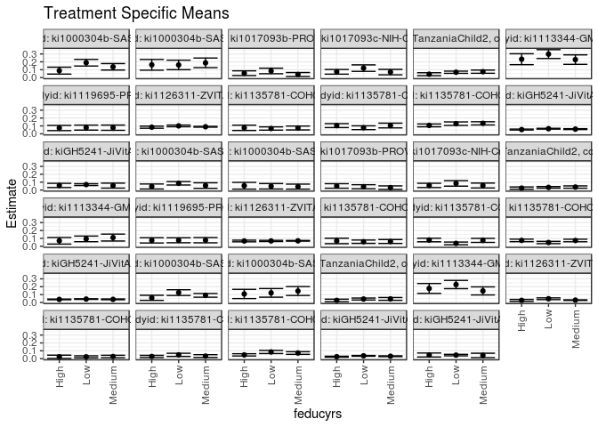

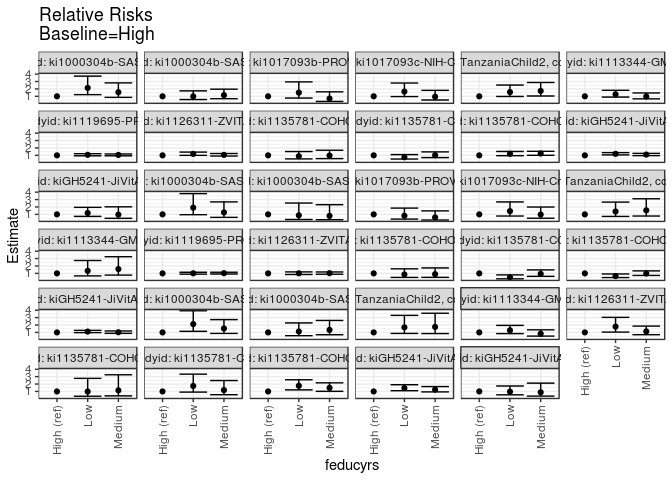

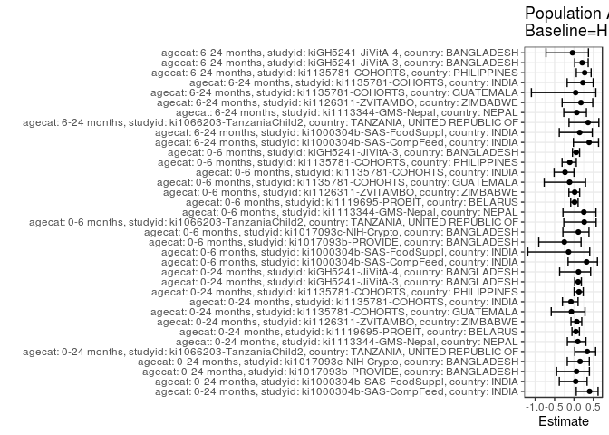

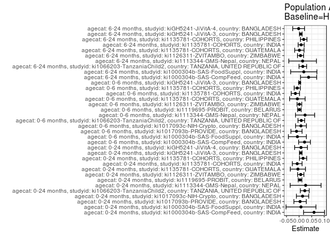

## Results Table

### Parameter: TSM

| agecat | studyid | country | intervention_level | baseline_level | estimate | ci_lower | ci_upper |
| --- | --- | --- | --- | --- | --- | --- | --- |
| 0-24 months | ki1000304b-SAS-CompFeed | INDIA | High | NA | 0.0882745 | 0.0443705 | 0.1321784 |
| 0-24 months | ki1000304b-SAS-CompFeed | INDIA | Low | NA | 0.1887480 | 0.1466493 | 0.2308466 |
| 0-24 months | ki1000304b-SAS-CompFeed | INDIA | Medium | NA | 0.1369567 | 0.0959377 | 0.1779756 |
| 0-24 months | ki1000304b-SAS-FoodSuppl | INDIA | High | NA | 0.1622967 | 0.0940589 | 0.2305345 |
| 0-24 months | ki1000304b-SAS-FoodSuppl | INDIA | Low | NA | 0.1607432 | 0.1003663 | 0.2211201 |
| 0-24 months | ki1000304b-SAS-FoodSuppl | INDIA | Medium | NA | 0.1872143 | 0.1262278 | 0.2482009 |
| 0-24 months | ki1017093b-PROVIDE | BANGLADESH | High | NA | 0.0560345 | 0.0264189 | 0.0856501 |
| 0-24 months | ki1017093b-PROVIDE | BANGLADESH | Low | NA | 0.0840336 | 0.0487611 | 0.1193061 |
| 0-24 months | ki1017093b-PROVIDE | BANGLADESH | Medium | NA | 0.0391304 | 0.0140529 | 0.0642079 |
| 0-24 months | ki1017093c-NIH-Crypto | BANGLADESH | High | NA | 0.0733141 | 0.0435125 | 0.1031158 |
| 0-24 months | ki1017093c-NIH-Crypto | BANGLADESH | Low | NA | 0.1202922 | 0.0790835 | 0.1615009 |
| 0-24 months | ki1017093c-NIH-Crypto | BANGLADESH | Medium | NA | 0.0698594 | 0.0354802 | 0.1042386 |
| 0-24 months | ki1066203-TanzaniaChild2 | TANZANIA, UNITED REPUBLIC OF | High | NA | 0.0433278 | 0.0248274 | 0.0618282 |
| 0-24 months | ki1066203-TanzaniaChild2 | TANZANIA, UNITED REPUBLIC OF | Low | NA | 0.0680352 | 0.0542036 | 0.0818668 |
| 0-24 months | ki1066203-TanzaniaChild2 | TANZANIA, UNITED REPUBLIC OF | Medium | NA | 0.0749431 | 0.0547009 | 0.0951853 |
| 0-24 months | ki1113344-GMS-Nepal | NEPAL | High | NA | 0.2336204 | 0.1643394 | 0.3029015 |
| 0-24 months | ki1113344-GMS-Nepal | NEPAL | Low | NA | 0.2982765 | 0.2422780 | 0.3542750 |
| 0-24 months | ki1113344-GMS-Nepal | NEPAL | Medium | NA | 0.2284450 | 0.1683210 | 0.2885691 |
| 0-24 months | ki1119695-PROBIT | BELARUS | High | NA | 0.0734960 | 0.0402459 | 0.1067461 |
| 0-24 months | ki1119695-PROBIT | BELARUS | Low | NA | 0.0786859 | 0.0469374 | 0.1104345 |
| 0-24 months | ki1119695-PROBIT | BELARUS | Medium | NA | 0.0775346 | 0.0442740 | 0.1107952 |
| 0-24 months | ki1126311-ZVITAMBO | ZIMBABWE | High | NA | 0.0840890 | 0.0707107 | 0.0974673 |
| 0-24 months | ki1126311-ZVITAMBO | ZIMBABWE | Low | NA | 0.1005949 | 0.0897484 | 0.1114415 |
| 0-24 months | ki1126311-ZVITAMBO | ZIMBABWE | Medium | NA | 0.0893583 | 0.0841899 | 0.0945266 |
| 0-24 months | ki1135781-COHORTS | GUATEMALA | High | NA | 0.0759957 | 0.0423376 | 0.1096538 |
| 0-24 months | ki1135781-COHORTS | GUATEMALA | Low | NA | 0.0671773 | 0.0465423 | 0.0878123 |
| 0-24 months | ki1135781-COHORTS | GUATEMALA | Medium | NA | 0.0738791 | 0.0491908 | 0.0985674 |
| 0-24 months | ki1135781-COHORTS | INDIA | High | NA | 0.1042281 | 0.0790092 | 0.1294469 |
| 0-24 months | ki1135781-COHORTS | INDIA | Low | NA | 0.0773829 | 0.0532709 | 0.1014949 |
| 0-24 months | ki1135781-COHORTS | INDIA | Medium | NA | 0.1052108 | 0.0753175 | 0.1351041 |

[output cut: 75 more lines]

### Parameter: E(Y)

| agecat | studyid | country | intervention_level | baseline_level | estimate | ci_lower | ci_upper |
| --- | --- | --- | --- | --- | --- | --- | --- |
| 0-24 months | ki1000304b-SAS-CompFeed | INDIA | NA | NA | 0.1476821 | 0.1188009 | 0.1765633 |
| 0-24 months | ki1000304b-SAS-FoodSuppl | INDIA | NA | NA | 0.1698565 | 0.1338154 | 0.2058975 |
| 0-24 months | ki1017093b-PROVIDE | BANGLADESH | NA | NA | 0.0600000 | 0.0423945 | 0.0776055 |
| 0-24 months | ki1017093c-NIH-Crypto | BANGLADESH | NA | NA | 0.0870712 | 0.0669870 | 0.1071555 |
| 0-24 months | ki1066203-TanzaniaChild2 | TANZANIA, UNITED REPUBLIC OF | NA | NA | 0.0658833 | 0.0559209 | 0.0758458 |
| 0-24 months | ki1113344-GMS-Nepal | NEPAL | NA | NA | 0.2595674 | 0.2244889 | 0.2946458 |
| 0-24 months | ki1119695-PROBIT | BELARUS | NA | NA | 0.0772908 | 0.0449502 | 0.1096314 |
| 0-24 months | ki1126311-ZVITAMBO | ZIMBABWE | NA | NA | 0.0906209 | 0.0857893 | 0.0954524 |
| 0-24 months | ki1135781-COHORTS | GUATEMALA | NA | NA | 0.0713128 | 0.0569485 | 0.0856771 |
| 0-24 months | ki1135781-COHORTS | INDIA | NA | NA | 0.0967519 | 0.0815150 | 0.1119888 |
| 0-24 months | ki1135781-COHORTS | PHILIPPINES | NA | NA | 0.1227336 | 0.1107225 | 0.1347447 |
| 0-24 months | kiGH5241-JiVitA-3 | BANGLADESH | NA | NA | 0.0604451 | 0.0569083 | 0.0639818 |
| 0-24 months | kiGH5241-JiVitA-4 | BANGLADESH | NA | NA | 0.0656057 | 0.0555292 | 0.0756822 |
| 0-6 months | ki1000304b-SAS-CompFeed | INDIA | NA | NA | 0.0665779 | 0.0427569 | 0.0903989 |
| 0-6 months | ki1000304b-SAS-FoodSuppl | INDIA | NA | NA | 0.0478469 | 0.0273607 | 0.0683330 |
| 0-6 months | ki1017093b-PROVIDE | BANGLADESH | NA | NA | 0.0414286 | 0.0266555 | 0.0562017 |
| 0-6 months | ki1017093c-NIH-Crypto | BANGLADESH | NA | NA | 0.0659631 | 0.0482810 | 0.0836451 |
| 0-6 months | ki1066203-TanzaniaChild2 | TANZANIA, UNITED REPUBLIC OF | NA | NA | 0.0331515 | 0.0259618 | 0.0403411 |
| 0-6 months | ki1113344-GMS-Nepal | NEPAL | NA | NA | 0.0931780 | 0.0699191 | 0.1164370 |
| 0-6 months | ki1119695-PROBIT | BELARUS | NA | NA | 0.0758337 | 0.0433525 | 0.1083150 |
| 0-6 months | ki1126311-ZVITAMBO | ZIMBABWE | NA | NA | 0.0679929 | 0.0637419 | 0.0722439 |
| 0-6 months | ki1135781-COHORTS | GUATEMALA | NA | NA | 0.0601805 | 0.0454109 | 0.0749501 |
| 0-6 months | ki1135781-COHORTS | INDIA | NA | NA | 0.0642202 | 0.0514517 | 0.0769887 |
| 0-6 months | ki1135781-COHORTS | PHILIPPINES | NA | NA | 0.0669690 | 0.0578174 | 0.0761205 |
| 0-6 months | kiGH5241-JiVitA-3 | BANGLADESH | NA | NA | 0.0410260 | 0.0379970 | 0.0440550 |
| 6-24 months | ki1000304b-SAS-CompFeed | INDIA | NA | NA | 0.0966811 | 0.0731505 | 0.1202117 |
| 6-24 months | ki1000304b-SAS-FoodSuppl | INDIA | NA | NA | 0.1268657 | 0.0942904 | 0.1594410 |
| 6-24 months | ki1066203-TanzaniaChild2 | TANZANIA, UNITED REPUBLIC OF | NA | NA | 0.0408163 | 0.0321620 | 0.0494707 |
| 6-24 months | ki1113344-GMS-Nepal | NEPAL | NA | NA | 0.1918506 | 0.1600242 | 0.2236769 |
| 6-24 months | ki1126311-ZVITAMBO | ZIMBABWE | NA | NA | 0.0321587 | 0.0287656 | 0.0355518 |
| 6-24 months | ki1135781-COHORTS | GUATEMALA | NA | NA | 0.0248889 | 0.0157815 | 0.0339963 |
| 6-24 months | ki1135781-COHORTS | INDIA | NA | NA | 0.0362989 | 0.0265157 | 0.0460822 |
| 6-24 months | ki1135781-COHORTS | PHILIPPINES | NA | NA | 0.0666667 | 0.0571766 | 0.0761568 |
| 6-24 months | kiGH5241-JiVitA-3 | BANGLADESH | NA | NA | 0.0317355 | 0.0287378 | 0.0347333 |
| 6-24 months | kiGH5241-JiVitA-4 | BANGLADESH | NA | NA | 0.0449219 | 0.0363514 | 0.0534923 |

### Parameter: RR

| agecat | studyid | country | intervention_level | baseline_level | estimate | ci_lower | ci_upper |
| --- | --- | --- | --- | --- | --- | --- | --- |
| 0-24 months | ki1000304b-SAS-CompFeed | INDIA | High | High | 1.0000000 | 1.0000000 | 1.0000000 |
| 0-24 months | ki1000304b-SAS-CompFeed | INDIA | Low | High | 2.1381937 | 1.2273148 | 3.7251013 |
| 0-24 months | ki1000304b-SAS-CompFeed | INDIA | Medium | High | 1.5514863 | 0.8569561 | 2.8089067 |
| 0-24 months | ki1000304b-SAS-FoodSuppl | INDIA | High | High | 1.0000000 | 1.0000000 | 1.0000000 |
| 0-24 months | ki1000304b-SAS-FoodSuppl | INDIA | Low | High | 0.9904282 | 0.5648332 | 1.7367039 |
| 0-24 months | ki1000304b-SAS-FoodSuppl | INDIA | Medium | High | 1.1535315 | 0.6768937 | 1.9657961 |
| 0-24 months | ki1017093b-PROVIDE | BANGLADESH | High | High | 1.0000000 | 1.0000000 | 1.0000000 |
| 0-24 months | ki1017093b-PROVIDE | BANGLADESH | Low | High | 1.4996768 | 0.7636284 | 2.9451898 |
| 0-24 months | ki1017093b-PROVIDE | BANGLADESH | Medium | High | 0.6983278 | 0.3042943 | 1.6025988 |
| 0-24 months | ki1017093c-NIH-Crypto | BANGLADESH | High | High | 1.0000000 | 1.0000000 | 1.0000000 |
| 0-24 months | ki1017093c-NIH-Crypto | BANGLADESH | Low | High | 1.6407776 | 0.9640402 | 2.7925716 |
| 0-24 months | ki1017093c-NIH-Crypto | BANGLADESH | Medium | High | 0.9528775 | 0.5033959 | 1.8037008 |
| 0-24 months | ki1066203-TanzaniaChild2 | TANZANIA, UNITED REPUBLIC OF | High | High | 1.0000000 | 1.0000000 | 1.0000000 |
| 0-24 months | ki1066203-TanzaniaChild2 | TANZANIA, UNITED REPUBLIC OF | Low | High | 1.5702434 | 0.9784458 | 2.5199804 |
| 0-24 months | ki1066203-TanzaniaChild2 | TANZANIA, UNITED REPUBLIC OF | Medium | High | 1.7296761 | 1.0434649 | 2.8671584 |
| 0-24 months | ki1113344-GMS-Nepal | NEPAL | High | High | 1.0000000 | 1.0000000 | 1.0000000 |
| 0-24 months | ki1113344-GMS-Nepal | NEPAL | Low | High | 1.2767569 | 0.8984639 | 1.8143280 |
| 0-24 months | ki1113344-GMS-Nepal | NEPAL | Medium | High | 0.9778471 | 0.6578722 | 1.4534509 |
| 0-24 months | ki1119695-PROBIT | BELARUS | High | High | 1.0000000 | 1.0000000 | 1.0000000 |
| 0-24 months | ki1119695-PROBIT | BELARUS | Low | High | 1.0706152 | 0.9370315 | 1.2232426 |
| 0-24 months | ki1119695-PROBIT | BELARUS | Medium | High | 1.0549497 | 0.9379794 | 1.1865068 |
| 0-24 months | ki1126311-ZVITAMBO | ZIMBABWE | High | High | 1.0000000 | 1.0000000 | 1.0000000 |
| 0-24 months | ki1126311-ZVITAMBO | ZIMBABWE | Low | High | 1.1962917 | 0.9946684 | 1.4387849 |
| 0-24 months | ki1126311-ZVITAMBO | ZIMBABWE | Medium | High | 1.0626631 | 0.9062930 | 1.2460131 |
| 0-24 months | ki1135781-COHORTS | GUATEMALA | High | High | 1.0000000 | 1.0000000 | 1.0000000 |
| 0-24 months | ki1135781-COHORTS | GUATEMALA | Low | High | 0.8839615 | 0.5160657 | 1.5141250 |
| 0-24 months | ki1135781-COHORTS | GUATEMALA | Medium | High | 0.9721480 | 0.5585261 | 1.6920818 |
| 0-24 months | ki1135781-COHORTS | INDIA | High | High | 1.0000000 | 1.0000000 | 1.0000000 |
| 0-24 months | ki1135781-COHORTS | INDIA | Low | High | 0.7424379 | 0.5004051 | 1.1015357 |
| 0-24 months | ki1135781-COHORTS | INDIA | Medium | High | 1.0094289 | 0.6949029 | 1.4663151 |

[output cut: 75 more lines]

### Parameter: PAR

| agecat | studyid | country | intervention_level | baseline_level | estimate | ci_lower | ci_upper |
| --- | --- | --- | --- | --- | --- | --- | --- |
| 0-24 months | ki1000304b-SAS-CompFeed | INDIA | High | NA | 0.0594076 | 0.0177874 | 0.1010278 |
| 0-24 months | ki1000304b-SAS-FoodSuppl | INDIA | High | NA | 0.0075598 | -0.0519820 | 0.0671015 |
| 0-24 months | ki1017093b-PROVIDE | BANGLADESH | High | NA | 0.0039655 | -0.0206446 | 0.0285756 |
| 0-24 months | ki1017093c-NIH-Crypto | BANGLADESH | High | NA | 0.0137571 | -0.0106858 | 0.0382000 |
| 0-24 months | ki1066203-TanzaniaChild2 | TANZANIA, UNITED REPUBLIC OF | High | NA | 0.0225555 | 0.0049545 | 0.0401565 |
| 0-24 months | ki1113344-GMS-Nepal | NEPAL | High | NA | 0.0259470 | -0.0354843 | 0.0873782 |
| 0-24 months | ki1119695-PROBIT | BELARUS | High | NA | 0.0037949 | -0.0034284 | 0.0110181 |
| 0-24 months | ki1126311-ZVITAMBO | ZIMBABWE | High | NA | 0.0065319 | -0.0060221 | 0.0190859 |
| 0-24 months | ki1135781-COHORTS | GUATEMALA | High | NA | -0.0046829 | -0.0348940 | 0.0255281 |
| 0-24 months | ki1135781-COHORTS | INDIA | High | NA | -0.0074762 | -0.0268337 | 0.0118814 |
| 0-24 months | ki1135781-COHORTS | PHILIPPINES | High | NA | 0.0158319 | 0.0014451 | 0.0302186 |
| 0-24 months | kiGH5241-JiVitA-3 | BANGLADESH | High | NA | 0.0065588 | 0.0013167 | 0.0118008 |
| 0-24 months | kiGH5241-JiVitA-4 | BANGLADESH | High | NA | 0.0076086 | -0.0178361 | 0.0330532 |
| 0-6 months | ki1000304b-SAS-CompFeed | INDIA | High | NA | 0.0216546 | -0.0018794 | 0.0451887 |
| 0-6 months | ki1000304b-SAS-FoodSuppl | INDIA | High | NA | -0.0066986 | -0.0424031 | 0.0290059 |
| 0-6 months | ki1017093b-PROVIDE | BANGLADESH | High | NA | -0.0102956 | -0.0324867 | 0.0118956 |
| 0-6 months | ki1017093c-NIH-Crypto | BANGLADESH | High | NA | 0.0073854 | -0.0143243 | 0.0290951 |
| 0-6 months | ki1066203-TanzaniaChild2 | TANZANIA, UNITED REPUBLIC OF | High | NA | 0.0087507 | -0.0045381 | 0.0220394 |
| 0-6 months | ki1113344-GMS-Nepal | NEPAL | High | NA | 0.0237065 | -0.0144348 | 0.0618478 |
| 0-6 months | ki1119695-PROBIT | BELARUS | High | NA | 0.0011751 | -0.0059641 | 0.0083143 |
| 0-6 months | ki1126311-ZVITAMBO | ZIMBABWE | High | NA | 0.0012302 | -0.0081706 | 0.0106310 |
| 0-6 months | ki1135781-COHORTS | GUATEMALA | High | NA | -0.0068694 | -0.0378325 | 0.0240936 |
| 0-6 months | ki1135781-COHORTS | INDIA | High | NA | -0.0147682 | -0.0313301 | 0.0017938 |
| 0-6 months | ki1135781-COHORTS | PHILIPPINES | High | NA | -0.0072660 | -0.0195460 | 0.0050140 |
| 0-6 months | kiGH5241-JiVitA-3 | BANGLADESH | High | NA | 0.0023598 | -0.0014132 | 0.0061327 |
| 6-24 months | ki1000304b-SAS-CompFeed | INDIA | High | NA | 0.0377456 | 0.0055675 | 0.0699237 |
| 6-24 months | ki1000304b-SAS-FoodSuppl | INDIA | High | NA | 0.0187045 | -0.0335474 | 0.0709564 |
| 6-24 months | ki1066203-TanzaniaChild2 | TANZANIA, UNITED REPUBLIC OF | High | NA | 0.0148319 | -0.0003549 | 0.0300187 |
| 6-24 months | ki1113344-GMS-Nepal | NEPAL | High | NA | 0.0140629 | -0.0410016 | 0.0691275 |
| 6-24 months | ki1126311-ZVITAMBO | ZIMBABWE | High | NA | 0.0057766 | -0.0065050 | 0.0180582 |
| 6-24 months | ki1135781-COHORTS | GUATEMALA | High | NA | 0.0010794 | -0.0176188 | 0.0197775 |
| 6-24 months | ki1135781-COHORTS | INDIA | High | NA | 0.0083296 | -0.0037083 | 0.0203674 |
| 6-24 months | ki1135781-COHORTS | PHILIPPINES | High | NA | 0.0183927 | 0.0054917 | 0.0312938 |
| 6-24 months | kiGH5241-JiVitA-3 | BANGLADESH | High | NA | 0.0067071 | 0.0012421 | 0.0121720 |
| 6-24 months | kiGH5241-JiVitA-4 | BANGLADESH | High | NA | -0.0017478 | -0.0253114 | 0.0218159 |

### Parameter: PAF

| agecat | studyid | country | intervention_level | baseline_level | estimate | ci_lower | ci_upper |
| --- | --- | --- | --- | --- | --- | --- | --- |
| 0-24 months | ki1000304b-SAS-CompFeed | INDIA | High | NA | 0.4022669 | 0.0582640 | 0.6206104 |
| 0-24 months | ki1000304b-SAS-FoodSuppl | INDIA | High | NA | 0.0445069 | -0.3785644 | 0.3377408 |
| 0-24 months | ki1017093b-PROVIDE | BANGLADESH | High | NA | 0.0660920 | -0.4482931 | 0.3977847 |
| 0-24 months | ki1017093c-NIH-Crypto | BANGLADESH | High | NA | 0.1579982 | -0.1726434 | 0.3954113 |
| 0-24 months | ki1066203-TanzaniaChild2 | TANZANIA, UNITED REPUBLIC OF | High | NA | 0.3423554 | 0.0200883 | 0.5586373 |
| 0-24 months | ki1113344-GMS-Nepal | NEPAL | High | NA | 0.0999624 | -0.1704063 | 0.3078747 |
| 0-24 months | ki1119695-PROBIT | BELARUS | High | NA | 0.0490983 | -0.0519233 | 0.1404183 |
| 0-24 months | ki1126311-ZVITAMBO | ZIMBABWE | High | NA | 0.0720791 | -0.0773189 | 0.2007593 |
| 0-24 months | ki1135781-COHORTS | GUATEMALA | High | NA | -0.0656674 | -0.5858708 | 0.2838969 |
| 0-24 months | ki1135781-COHORTS | INDIA | High | NA | -0.0772714 | -0.2968530 | 0.1051310 |
| 0-24 months | ki1135781-COHORTS | PHILIPPINES | High | NA | 0.1289938 | 0.0041921 | 0.2381545 |
| 0-24 months | kiGH5241-JiVitA-3 | BANGLADESH | High | NA | 0.1085078 | 0.0178216 | 0.1908208 |
| 0-24 months | kiGH5241-JiVitA-4 | BANGLADESH | High | NA | 0.1159740 | -0.3700777 | 0.4295930 |
| 0-6 months | ki1000304b-SAS-CompFeed | INDIA | High | NA | 0.3252525 | -0.1519484 | 0.6047703 |
| 0-6 months | ki1000304b-SAS-FoodSuppl | INDIA | High | NA | -0.1400000 | -1.1896424 | 0.4064785 |
| 0-6 months | ki1017093b-PROVIDE | BANGLADESH | High | NA | -0.2485137 | -0.9073454 | 0.1827456 |
| 0-6 months | ki1017093c-NIH-Crypto | BANGLADESH | High | NA | 0.1119624 | -0.2855570 | 0.3865610 |
| 0-6 months | ki1066203-TanzaniaChild2 | TANZANIA, UNITED REPUBLIC OF | High | NA | 0.2639605 | -0.2619481 | 0.5707001 |
| 0-6 months | ki1113344-GMS-Nepal | NEPAL | High | NA | 0.2544213 | -0.2838553 | 0.5670169 |
| 0-6 months | ki1119695-PROBIT | BELARUS | High | NA | 0.0154955 | -0.0840266 | 0.1058807 |
| 0-6 months | ki1126311-ZVITAMBO | ZIMBABWE | High | NA | 0.0180934 | -0.1303916 | 0.1470739 |
| 0-6 months | ki1135781-COHORTS | GUATEMALA | High | NA | -0.1141467 | -0.7679324 | 0.2978675 |
| 0-6 months | ki1135781-COHORTS | INDIA | High | NA | -0.2299613 | -0.5125876 | -0.0001436 |
| 0-6 months | ki1135781-COHORTS | PHILIPPINES | High | NA | -0.1084983 | -0.3067952 | 0.0597084 |
| 0-6 months | kiGH5241-JiVitA-3 | BANGLADESH | High | NA | 0.0575185 | -0.0387656 | 0.1448780 |
| 6-24 months | ki1000304b-SAS-CompFeed | INDIA | High | NA | 0.3904132 | -0.0149859 | 0.6338904 |
| 6-24 months | ki1000304b-SAS-FoodSuppl | INDIA | High | NA | 0.1474355 | -0.3788951 | 0.4728633 |
| 6-24 months | ki1066203-TanzaniaChild2 | TANZANIA, UNITED REPUBLIC OF | High | NA | 0.3633813 | -0.1280748 | 0.6407301 |
| 6-24 months | ki1113344-GMS-Nepal | NEPAL | High | NA | 0.0733015 | -0.2629094 | 0.3200066 |
| 6-24 months | ki1126311-ZVITAMBO | ZIMBABWE | High | NA | 0.1796272 | -0.3059002 | 0.4846378 |
| 6-24 months | ki1135781-COHORTS | GUATEMALA | High | NA | 0.0433673 | -1.0976561 | 0.5637292 |
| 6-24 months | ki1135781-COHORTS | INDIA | High | NA | 0.2294713 | -0.1760164 | 0.4951477 |
| 6-24 months | ki1135781-COHORTS | PHILIPPINES | High | NA | 0.2758910 | 0.0596804 | 0.4423875 |
| 6-24 months | kiGH5241-JiVitA-3 | BANGLADESH | High | NA | 0.2113426 | 0.0184032 | 0.3663585 |
| 6-24 months | kiGH5241-JiVitA-4 | BANGLADESH | High | NA | -0.0389065 | -0.7210056 | 0.3728511 |